# CFRM 502, Winter 2020

# Instructor: Bahman Angoshtari

# Solution to Homework 2

$\newcommand\Fc{\mathscr{F}}$ $\newcommand{\eps}{\varepsilon}$ $\newcommand{\Var}{\operatorname{Var}}$ $\newcommand\Cov{\operatorname{Cov}}$ $\newcommand\Corr{\operatorname{Corr}}$ $\newcommand{\sig}{\sigma}$ $\newcommand\Sig{\Sigma}$ $\newcommand{\al}{\alpha}$ $\newcommand{\gam}{\gamma}$ $\newcommand\Gam{\Gamma}$ $\newcommand\lam{\lambda}$ $\newcommand{\Del}{\Delta}$ $\newcommand\tht{\theta}$ $\newcommand\ph{\varphi}$ $\newcommand\om{\omega}$ $\newcommand\Om{\Omega}$ $\newcommand\rb{\bar{r}}$ $\newcommand{\Xb}{\bar{X}}$ $\newcommand{\Yb}{\bar{Y}}$ $\newcommand\Eb{\mathbb{E}}$ $\newcommand\Pb{\mathbb{P}}$ $\newcommand\Qb{\mathbb{Q}}$ $\newcommand\Rb{\mathbb{R}}$ $\newcommand\Zb{\mathbb{Z}}$ $\newcommand\Nb{\mathbb{N}}$ $\newcommand\Av{\textbf{A}}$ $\newcommand\Ev{\textbf{E}}$ $\newcommand\Dv{\textbf{D}}$ $\newcommand\Fv{\textbf{F}}$ $\newcommand\Gv{\textbf{G}}$ $\newcommand\Hv{\textbf{H}}$ $\newcommand\Kv{\textbf{K}}$ $\newcommand\Iv{\textbf{I}}$ $\newcommand\Pv{\textbf{P}}$ $\newcommand\Ov{\textbf{O}}$ $\newcommand\Sv{\textbf{S}}$ $\newcommand\Xv{\textbf{X}}$ $\newcommand\Yv{\textbf{Y}}$ $\newcommand\Zv{\textbf{Z}}$ $\newcommand\av{\mathbf{a}}$ $\newcommand\xv{\mathbf{x}}$ $\newcommand\yv{\mathbf{y}}$ $\newcommand\zv{\mathbf{z}}$ $\newcommand\Cv{\mathbf{C}}$ $\newcommand\mv{\mathbf{m}}$ $\newcommand\nv{\mathbf{n}}$ $\newcommand\pv{\mathbf{p}}$ $\newcommand\sv{\mathbf{s}}$ $\newcommand\wv{\mathbf{w}}$ $\newcommand\Wv{\textbf{W}}$ $\newcommand\alv{{\boldsymbol\al}}$ $\newcommand\betav{{\boldsymbol\beta}}$ $\newcommand\etav{{\boldsymbol\eta}}$ $\newcommand\epsv{{\boldsymbol\varepsilon}}$ $\newcommand\delv{{\boldsymbol\delta}}$ $\newcommand\Lamv{{\boldsymbol\Lambda}}$ $\newcommand\lamv{{\boldsymbol\lambda}}$ $\newcommand\muv{{\boldsymbol\mu}}$ $\newcommand\piv{{\boldsymbol\pi}}$ $\newcommand\Piv{{\boldsymbol\Pi}}$ $\newcommand\Gamv{{\boldsymbol\Gam}}$ $\newcommand\Phiv{{\boldsymbol\Phi}}$ $\newcommand\Sigv{{\boldsymbol\Sig}}$ $\newcommand\ah{\widehat{a}}$ $\newcommand\Pbh{\widehat{\Pb}}$ $\newcommand\phh{\widehat{\varphi}}$ $\newcommand\Ebh{\widehat{\Eb}}$ $\newcommand\Qh{\widehat{Q}}$ $\newcommand\Ih{\widehat{I}}$ $\newcommand\rh{\widehat{r}}$ $\newcommand\pih{\widehat{\pi}}$ $\newcommand\Pih{\widehat{\Pi}}$ $\newcommand\Sigvh{\widehat{\Sigv}}$ $\newcommand\Wh{\widehat{W}}$ $\newcommand\Fh{\widehat{F}}$ $\newcommand\Yh{\widehat{Y}}$ $\newcommand\Zh{\widehat{Z}}$ $\newcommand\Yvh{\widehat{\Yv}}$ $\newcommand\Ah{\widehat{\Ac}}$ $\newcommand\uh{\widehat{u}}$ $\newcommand\vh{\widehat{v}}$ $\newcommand\fh{\widehat{f}}$ $\newcommand\hh{\widehat{h}}$ $\newcommand\Bh{\widehat{B}}$ $\newcommand\Ovh{\widehat{\Ov}}$ $\newcommand\Xvh{\widehat{\Xv}}$ $\newcommand\rhoh{\widehat{\rho}}$ $\newcommand\nuh{\widehat{\nu}}$ $\newcommand\varphih{\widehat{\varphi}}$ $\newcommand\alh{\widehat{\al}}$ $\newcommand\thetah{\widehat{\theta}}$ $\newcommand\betah{\widehat{\beta}}$ $\newcommand\betavh{\widehat{\boldsymbol\beta}}$ $\newcommand\kaph{\widehat{\kappa}}$ $\newcommand\sigh{\widehat{\sigma}}$ $\newcommand\epsh{\widehat{\eps}}$ $\newcommand\epsvh{\widehat{\epsv}}$ $\newcommand\epst{\widetilde{\eps}}$ $\newcommand\muh{\widehat{\mu}}$ $\newcommand\dd{\mathrm{d}}$ $\newcommand\ee{\mathrm{e}}$ $\newcommand{\var}[1]{\text{Var} \left( #1 \right)}$

The following code sets up graphics in the Juypter notebook.

```r
# Configuring plots in the Jupyter notebook
options(repr.plot.pointsize = 20, # Text height in pt
        repr.plot.bg        = 'white',
        repr.plot.antialias = 'gray',
        #jpeg quality bumped from default
        repr.plot.quality   = 90,
        #vector font family
        repr.plot.family    = 'serif') # Vector font family. 'sans', 'serif', 'mono' or a specific one
```

# 1.

Consider the mutual fund `AMRMX` and 4 exchange traded funds (ETFs) with the symbols `IWD`, `IWF`, `IWO`, and `VONG`. Use the R package `quantmod` (using Yahoo! Finance as the source) to obtain price series from January 3, 2011 to December 29, 2016.

## (a)

(2 points) Compute the daily log returns of the 5 symbols. Produce a scatter plot and a correlation plot. Interpret the plots.

**Solution:**

First, we get the adjusted prices and calculate the returns.

```r
library(quantmod)
getSymbols(c("AMRMX","IWD","IWF", "IWO","VONG"), from="2011-01-03", to="2016-12-29", src="yahoo")
dat <- na.locf(merge(AMRMX$AMRMX.Adjusted,IWD$IWD.Adjusted,IWF$IWF.Adjusted,IWO$IWO.Adjusted,VONG$VONG.Adjusted))[index(AMRMX)]
ret = diff(log(dat))[-1,]
names(ret) = c("AMRMX","IWD","IWF", "IWO","VONG")
ret = coredata(ret)
DF_Q1 <- data.frame(AMRMX=ret[,"AMRMX"],
                    IWD=ret[,"IWD"],
                    IWF=ret[,"IWF"],
                    IWO=ret[,"IWO"],
                    VONG=ret[,"VONG"])
```

[output not shown]

1. 'AMRMX'

2. 'IWD'

3. 'IWF'

4. 'IWO'

5. 'VONG'

Next, we find the scatter plots.

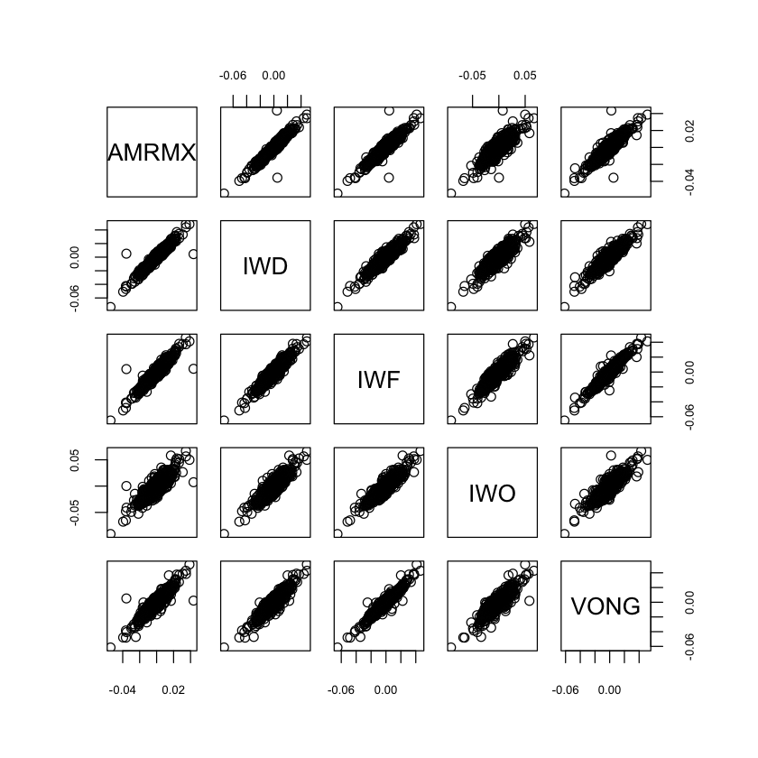

```r
pairs(~., data=DF_Q1)
```

Finally, we obtain correlation plot.

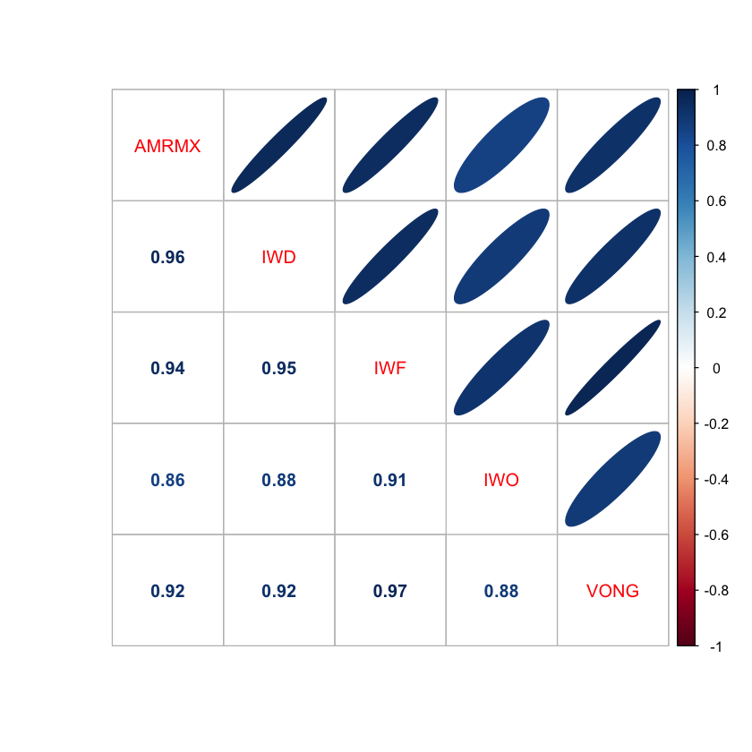

```r
library(corrplot)
corrplot.mixed(cor(DF_Q1),upper="ellipse")
```

All the samples are highly correlated.

## (b)

(2 points) Fit a regression model with AMRMX as the response and the ETFs as predictors. State the value of the coefficients of the regression. Are the coefficients significant under 5\% significance level? What is the sample correlation between fitted and observed values of AMRMX?

The coefficients of IWD, IWF, and IWO are significant. The intercept and the coefficient of VONG are not significant.

```r
fit_Q1b <- lm(AMRMX ~ ., data = DF_Q1)
summary(fit_Q1b)
```

```
Call:
lm(formula = AMRMX ~ ., data = DF_Q1)

Residuals:
      Min        1Q    Median        3Q       Max
-0.039994 -0.000878 -0.000015  0.000889  0.040108

Coefficients:
              Estimate Std. Error t value Pr(>|t|)
(Intercept)  3.609e-05  5.193e-05   0.695    0.487
IWD          5.434e-01  1.641e-02  33.105  < 2e-16 ***
IWF          3.377e-01  2.917e-02  11.576  < 2e-16 ***
IWO         -7.343e-02  9.753e-03  -7.529 8.76e-14 ***
VONG         2.870e-02  2.285e-02   1.256    0.209
---
Signif. codes:  0 ‘***’ 0.001 ‘**’ 0.01 ‘*’ 0.05 ‘.’ 0.1 ‘ ’ 1

Residual standard error: 0.002013 on 1502 degrees of freedom
Multiple R-squared:  0.9383,	Adjusted R-squared:  0.9382
F-statistic:  5715 on 4 and 1502 DF,  p-value: < 2.2e-16
```

```r
cor(DF_Q1$AMRMX,fitted(fit_Q1b))
```

0.968683241203956

## (c)

(2 points) Obtain the ANOVA table for the model in part (b), and interpret it. What is the total sum of squares of the model?

**Solution:** The ANOVA table is as follows.

```r
anova(fit_Q1b)
```

A anova: 5 × 5

|  | Df <int> | Sum Sq <dbl> | Mean Sq <dbl> | F value <dbl> | Pr(>F) <dbl> |
| --- | --- | --- | --- | --- | --- |
| IWD | 1 | 9.112325e-02 | 9.112325e-02 | 22495.491917 | 0.000000e+00 |
| IWF | 1 | 1.237741e-03 | 1.237741e-03 | 305.559683 | 1.998322e-62 |
| IWO | 1 | 2.333808e-04 | 2.333808e-04 | 57.614451 | 5.568175e-14 |
| VONG | 1 | 6.390138e-06 | 6.390138e-06 | 1.577526 | 2.093127e-01 |
| Residuals | 1502 | 6.084202e-03 | 4.050734e-06 | NA | NA |

Since the incremental F-tests are highly significant for IWD, IWF, and IWO, these predictors contain information that is not in the previous predictors. VONG on the other hand, has no predictive power that is not already included in IWD, IWF, and IWO.

## (d)

(2 points) Do a F-test to see if the coefficients of `IWO` and `VONG` and the intercept are simultaneously zero. That is, the null hypothesis is $\beta_{\text{IWO}} = \beta_{\text{VONG}} = \beta_0=0$.

**Solution:** According to the following R output, the null hypothesis is rejected. This was expected, since $\betah_{\text{IWO}}$ is significant.

```r
ModelI = lm(AMRMX ~ IWD + IWF -1, data = DF_Q1)
ModelII = fit_Q1b
anova(ModelI, ModelII)
```

A anova: 2 × 6

| Res.Df <dbl> | RSS <dbl> | Df <dbl> | Sum of Sq <dbl> | F <dbl> | Pr(>F) <dbl> |
| --- | --- | --- | --- | --- | --- |
| 1505 | 0.006327635 | NA | NA | NA | NA |
| 1502 | 0.006084202 | 3 | 0.0002434332 | 20.03202 | 9.878995e-13 |

## (e)

(2 points) If you can only choose one ETF (and the intercept) as the predictor, which one would you choose? What if you can choose 2 predictors? You must support your answers using appropriate R outputs.

**Solution:** The following code finds the best models according to BIC, C$_p$, and R$^2$. The `IWD` is the best single predictor. `IWD` and `IWF` are the best pair. And, IWD, IWF, IWO are the best triplet.

```r
library(leaps)
subsets = regsubsets(AMRMX~., data=DF_Q1, nbest=1)
b = summary(subsets)
b
```

```
Subset selection object
Call: regsubsets.formula(AMRMX ~ ., data = DF_Q1, nbest = 1)
4 Variables  (and intercept)
     Forced in Forced out
IWD      FALSE      FALSE
IWF      FALSE      FALSE
IWO      FALSE      FALSE
VONG     FALSE      FALSE
1 subsets of each size up to 4
Selection Algorithm: exhaustive
         IWD IWF IWO VONG
1  ( 1 ) "*" " " " " " "
2  ( 1 ) "*" "*" " " " "
3  ( 1 ) "*" "*" "*" " "
4  ( 1 ) "*" "*" "*" "*"
```

## (f)

(2 points) Find the best set of predictors based on BIC criterion.

**Solution:** We compare the BIC of the models with different number of predictors. As the following R output indicates, the three predictor model has the lowest value of BIC. Thus, IWD, IWF, IWO are the best set of predictors.

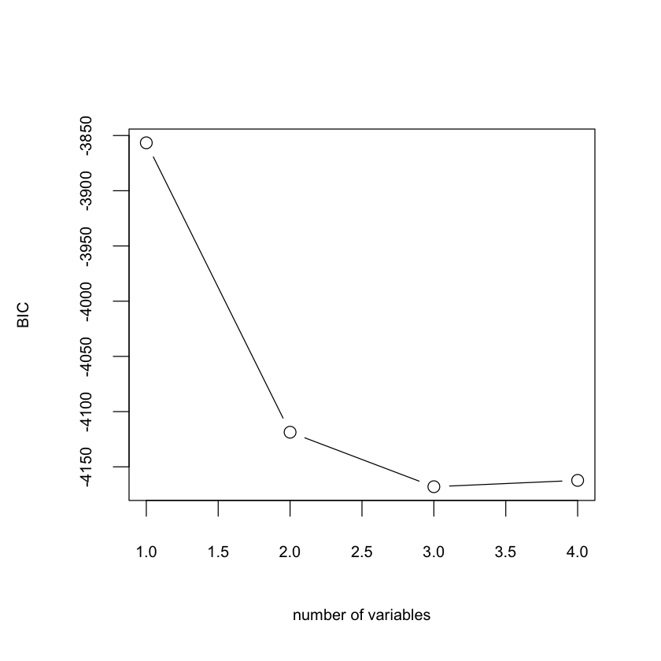

```r
plot(1:4,b$bic,type="b",xlab="number of variables", ylab="BIC")
```

## (g)

(2 points) Do you see any evidence of collinearity between the predictors? Justify your answer by an appropriate R output.

**Solution:** From the correlation plot of part (a), it is evident that the predictor are highly collinear. Alternatively, we may check the VIF values. According to the following R output, the VIF values are quite high, which confirms high collinearity.

```r
library(faraway)
vif(fit_Q1b)
```

**IWD**

9.5766874975143

**IWF**

29.3193816444552

**IWO**

6.23882937260025

**VONG**

17.8577910303459

# 2.

(3 points) Solve exercise 9, in section 9.12 of the textbook. Explain your answers.

**Solution:**

The answer is:

\begin{equation*} \begin{array}{l c c c c c} Source & df & SS & MS & F & P-value\\ Regression & 2 & 3.627186 &1.813593& 4.165496& {\color{black}0.04}\\ Error (residuals) & 13 &{\color{black}5.66}&0.4353846& & \\ Total &{\color{black}15} & 9.287186 & & & \\ R-sq = 0.391 & & & & & \\ \end{array} \end{equation*}

The table is completed in the following order.

1. Regression d.f. is 2 since there are 2 predictors.
2. Residual d.f. = total d.f. - regression d.f. = 13.
3. F-test statistic is $1-0.04=0.96$-th quantile of an F-distribution with 2 and 13 degrees of freedom. Thus, $F=4.165496$. Use R command `qf(0.96, 2, 13)`.
4. Residual MS = $\sigh^2_\eps = \frac{\text{residual SS}}{\text{residual d.f.}} = \frac{5.66}{13}=0.435385$.
5. Regression MS = F $\times$ $\sigh^2_\eps$ = $4.165496 \times 0.4353846 = 1.813593$.
6. Regression SS = regression MS $\times$ regression d.f. = $1.813593\times 2 = 3.627186$.
7. Total SS = residual SS + regression SS = $5.66 + 3.627186 = 9.287186$.
8. R$^2$ = $\frac{\text{regression SS}}{\text{total SS}} = \frac{3.627186}{9.287186}\approx 0.391$.

# 3.

The forward-rate curve is an important tool for modeling the term-structure of interest rates. It is given by

\begin{align*} r(t) = -\frac{\partial}{\partial t} \log P(t), \end{align*}

where $P(t)$ is the price of a zero-coupon bond with maturity t. The forward-rate curve cannot be directly observed from the market, and one way to estimate it is by using the prices of zero-coupon bonds with different maturities. Specifically, let $P(t_0)$, $P(t_1), \dots ,P(t_n)$ be the prices of $n+1$ zero-coupon bonds. Then, $r(t_i)$, the forward-rate curve at $t_i$, is estimated by the "empirical forward-rate estimates" $\rh_i$ given by

\begin{align*} \rh_i := -\frac{\log P(t_i) - \log P(t_{i-1})}{t_i - t_{i-1}};\quad i\in\{1, \dots, n\}. \end{align*}

These estimates are noisy. To obtain a forward rate, one needs to fit a `curve` through the points $(t_1, \rh_1), \dots, (t_n, \rh_n)$. This will be our main goal for this problem.

The text file `HW2-data.txt` that is posted with this homework, includes the prices of 117 zero-coupon bonds with equally spaced maturities from 0 to 30 years. The following code snippet loads the data and stores the empirical forward-rate estimates and the corresponding maturities in the variables `EMP` and `MAT`, respectively. When running the code, make sure that the text file is in your working directory.

```r
dat = read.table("HW2-data.txt",header=TRUE)
dat = dat[order(dat$T),]
EMP = -diff(log(dat$price))/diff(dat$T)
MAT = dat$T[-1]
```

The following graph shows a scatterplot of the empirical forward-rate (EMP) vs. maturity (MAT). Clearly, the forward rate curve is not linear.

[figure not shown]

## (a)

(1 points) Ignoring the nonlinearity, we decide to fit a line regression $\text{EMP}_i = \beta_0 + \beta_1 \text{MAT}_i+ \eps_i$ to the data. Fit this model (i.e. express the estimated parameters) and provide a scatter plot of the predictor and the response along with the fitted line.

```r
fit_Q3a <- lm(EMP ~ MAT)
summary(fit_Q3a)
```

```
Call:
lm(formula = EMP ~ MAT)

Residuals:
      Min        1Q    Median        3Q       Max
-0.032614 -0.005610  0.001650  0.005943  0.014269

Coefficients:
             Estimate Std. Error t value Pr(>|t|)
(Intercept) 6.011e-02  1.451e-03  41.413   <2e-16 ***
MAT         1.775e-05  8.559e-05   0.207    0.836
---
Signif. codes:  0 ‘***’ 0.001 ‘**’ 0.01 ‘*’ 0.05 ‘.’ 0.1 ‘ ’ 1

Residual standard error: 0.007717 on 114 degrees of freedom
Multiple R-squared:  0.0003771,	Adjusted R-squared:  -0.008391
F-statistic: 0.04301 on 1 and 114 DF,  p-value: 0.8361
```

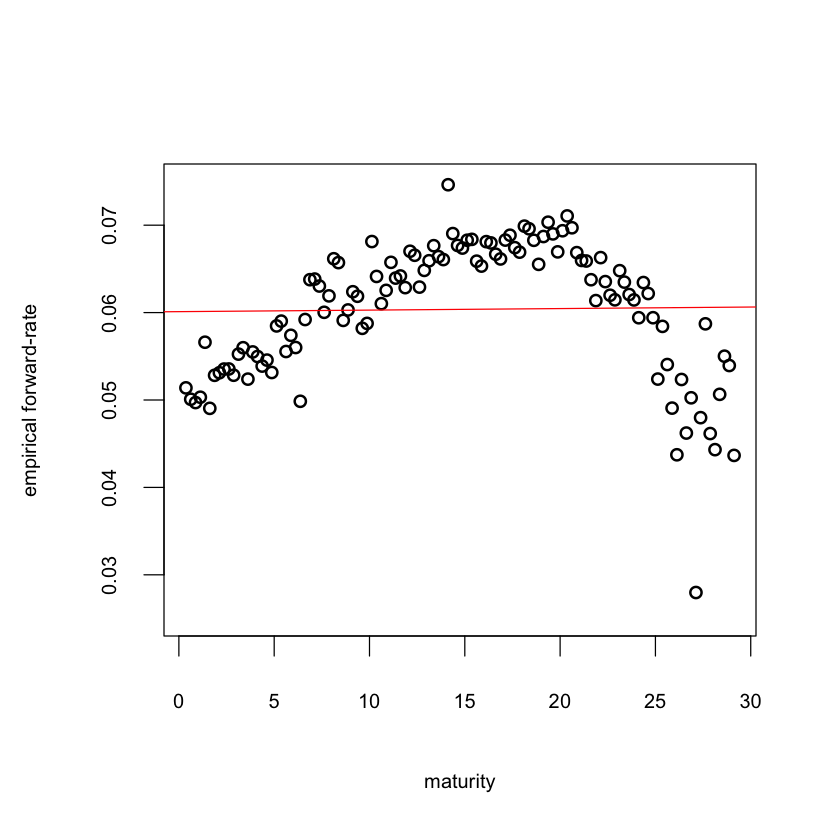

```r
plot(MAT,EMP,ylim=c(0.025,.075),lwd=2,xlab="maturity",
     ylab="empirical forward-rate",cex=.75)
abline(fit_Q3a, col=2)
```

## (b)

(3 points) Check the fitted model in part (a) for the following anomalies: high-leverage points, residual outliers, and high-influence points. Explain your answers and provide necessary plots to justify them.

**Solution:** According to the R output below:

- The leverage plot indicates no high-leverage point, since there is no point with leverage value above the twice the average leverage values.
- The residual plot indicates one extreme residual outlier with absolute value greater than 3 (three time the standard deviation of rstudent). Here, rstudent must be used.
- The half normal plot of the Cook's D indicate one high-influence point (observation 108), which is apart from the other points.

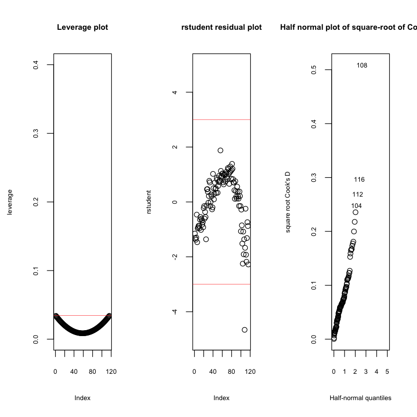

```r
# Leverage plot
par(mfrow=c(1,3))
plot(hatvalues(fit_Q3a), ylab="leverage",main="Leverage plot", ylim=c(0,0.4))
p=1;n=length(EMP);
abline(h=2*((p+1)/n),lwd=0.5,col=2)
# Residual plot
min_rstudent = min(rstudent(fit_Q3a))
max_rstudent = max(rstudent(fit_Q3a))
plot(rstudent(fit_Q3a),
     ylim = c(min(-5, min_rstudent), max(5, max_rstudent)),
     ylab="rstudent",main="rstudent residual plot")
abline(h=c(-3, 3),lwd=0.5,col=2)
# Half normal plot of square-root of Cook's D
library(faraway) # needed for half normal plots
halfnorm(sqrt(cooks.distance(fit_Q3a)), xlim=c(0,5), nlab = 4,
         ylab=("square root Cook's D"),
         main="Half normal plot of square-root of Cook's D")
```

## (c)

(4 points) Check the model in part (a) for non-normality, non-constant variance of residuals, nonlinear relation between response and predictor, as well as spurious regression. Explain your answers and provide supporting plots.

**Solution:**

The norm probability plot of rstudent indicates non-normality. The residuals seem to be left-skewed.

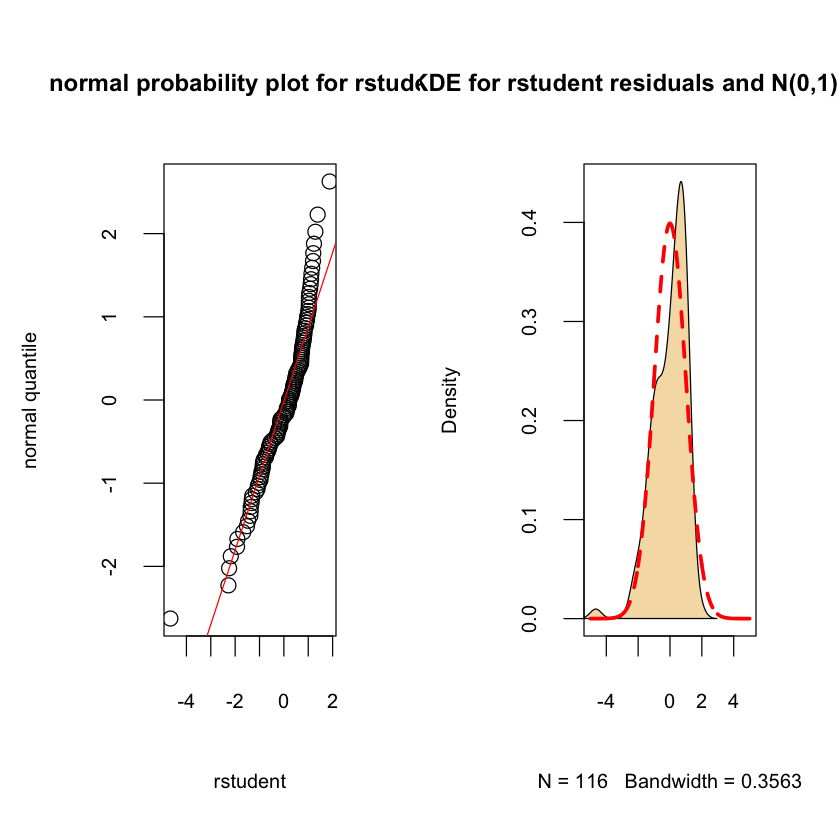

```r
par(mfrow=c(1,2))
qqnorm(rstudent(fit_Q3a), datax = TRUE,
       xlab = "normal quantile", # this is for the theoretical quantiles
       ylab = "rstudent", # this is for the sample quantiles
       main = "normal probability plot for rstudent")
qqline(rstudent(fit_Q3a), datax=TRUE, col = 2)
d <- density(rstudent(fit_Q3a), adjust = 1, na.rm = TRUE)
plot(d, type = "n", xlim=c(-5,5), main="KDE for rstudent residuals and N(0,1) density") # more sophisticated plot
polygon(d, col = "wheat")
z = seq(from=-5,to=5,by=.01)
lines(z,dnorm(z), lty=2,lwd=3,col="red")
```

To check for non-constant variance, we plot the absolute value of rstudent vs the fitted value and fit a scatterplot smoother. It seems that residuals have higher variance in for extreme fitted values.

To check for non-linearity, we plot rstudent vs. the predictor (MAT). It clearly shows a nonlinear trend, highlighted by the scatterplot smoother.

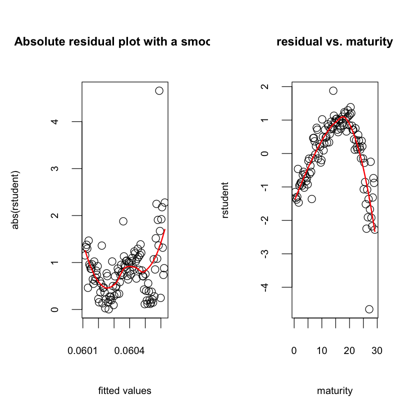

```r
par(mfrow=c(1,2))
# Checking for constant variance absolute residual plot with a scatterplot smoother
plot(fitted(fit_Q3a), abs(rstudent(fit_Q3a)),
     xlab = "fitted values", ylab = "abs(rstudent)",
     main = "Absolute residual plot with a smoother")
smoother = loess(abs(rstudent(fit_Q3a)) ~ fitted(fit_Q3a))
ord = order(fitted(fit_Q3a)) # why do we need this line?
lines(fitted(fit_Q3a)[ord], fitted(smoother)[ord], col="red", lwd=2)
# Checking for nonlinearity
plot(MAT, rstudent(fit_Q3a),
     xlab = "maturity", ylab = "rstudent",
     main = "residual vs. maturity")
smoother = loess(rstudent(fit_Q3a) ~ MAT)
ord = order(MAT)
lines(MAT[ord], fitted(smoother)[ord], col="red", lwd=2)
```

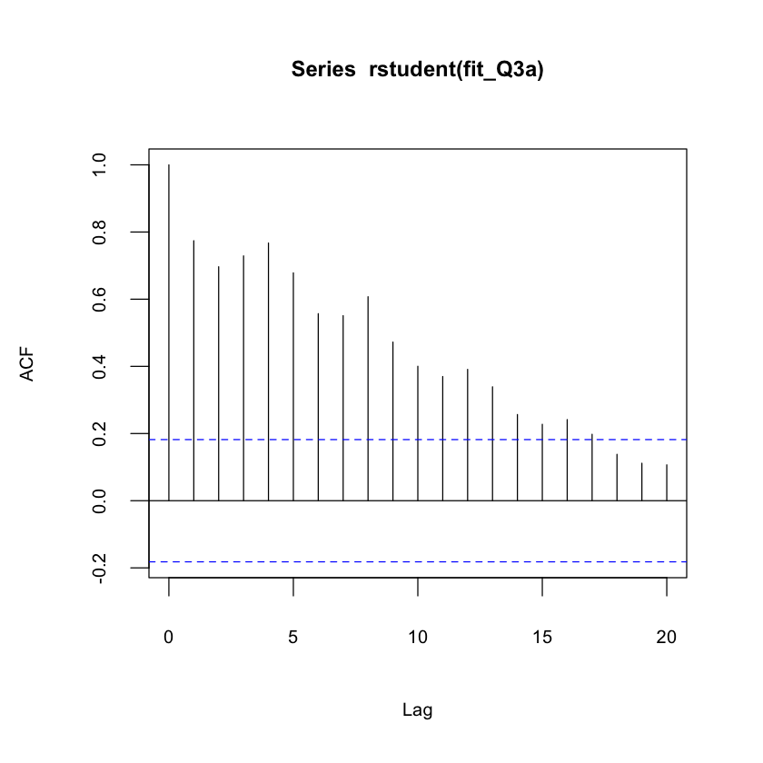

```r
acf(rstudent(fit_Q3a))
```

## (d)

(2 points) Not satisfied with the model in part (a), we decide to use a cubic regression model

\begin{align*} \text{EMP}_i = \beta_0 + \beta_1 \,\text{MAT}_i + \beta_2 \,\text{MAT}^2_i + \beta_3\, \text{MAT}^3_i + \eps_i. \end{align*}

Fit this model using a multiple linear regression model. Specify the estimated parameters $\betah_0,\dots,\betah_3$ and provide a scatter plot of the EMP versus MAT along with the fitted curve. You are only allowed to use the R function `lm()` to fit the model.

**Solution:** We treat $X_1=\text{MAT}$, $X_2=\text{MAT}^2$, and $X_3=\text{MAT}^3$ as three different predictors and fit a multiple regression model. The estimated model is

\begin{align*} \text{EMP}_i = 0.04978 + 0.001168 \,\text{MAT}_i + 5.523\times 10^{-05}\,\text{MAT}^2_i -3.569\times 10^{-06} \beta_3\, \text{MAT}^3_i + \eps_i. \end{align*}

```r
MAT2 = MAT**2
MAT3 = MAT**3
fit_Q3d <- lm(EMP ~ MAT + MAT2 + MAT3)
summary(fit_Q3d)
```

```
Call:
lm(formula = EMP ~ MAT + MAT2 + MAT3)

Residuals:
       Min         1Q     Median         3Q        Max
-0.0228816 -0.0015683  0.0001371  0.0014573  0.0103183

Coefficients:
              Estimate Std. Error t value Pr(>|t|)
(Intercept)  4.978e-02  1.530e-03  32.546  < 2e-16 ***
MAT          1.168e-03  4.452e-04   2.623  0.00994 **
MAT2         5.523e-05  3.491e-05   1.582  0.11646
MAT3        -3.569e-06  7.784e-07  -4.585 1.19e-05 ***
---
Signif. codes:  0 ‘***’ 0.001 ‘**’ 0.01 ‘*’ 0.05 ‘.’ 0.1 ‘ ’ 1

Residual standard error: 0.003863 on 112 degrees of freedom
Multiple R-squared:  0.7539,	Adjusted R-squared:  0.7474
F-statistic: 114.4 on 3 and 112 DF,  p-value: < 2.2e-16
```

The following R code yield the scatter plot and the fitted cubic curve.

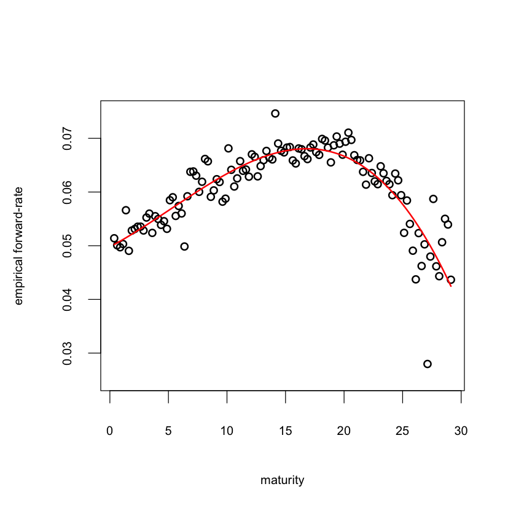

```r
plot(MAT,EMP,ylim=c(0.025,.075),lwd=2,xlab="maturity",
     ylab="empirical forward-rate",cex=.75)
ord = order(MAT)
lines(MAT[ord], fitted(fit_Q3d)[ord], col="red", lwd=2)
```

## (e)

(7 points) Repeat parts (b) and (c) for the model in part (d).

**Solution:**

- Leverage plot shows high-leverage points for short and long maturities.
- The residual plot indicates one residual outlier as in part (b). The half normal plot of the Cook's D shows a high-influence point as well.

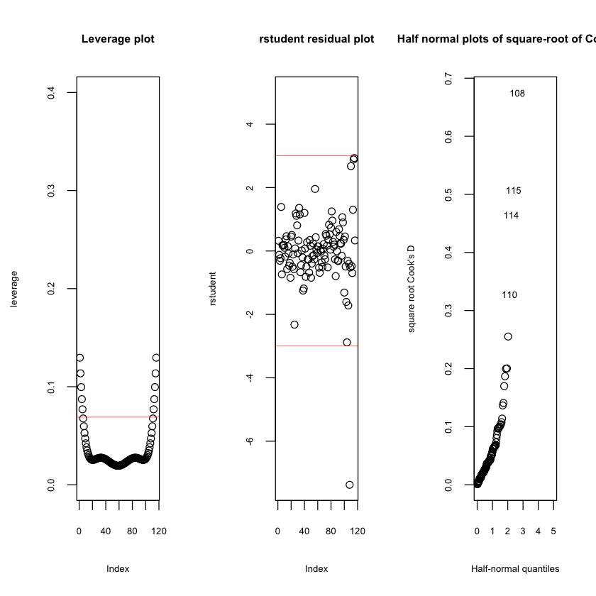

```r
par(mfrow=c(1,3))
plot(hatvalues(fit_Q3d), ylab="leverage",
     main="Leverage plot", ylim=c(0,0.4))
p=3;n=length(EMP);
abline(h=2*((p+1)/n),lwd=0.5,col=2)

min_rstudent = min(rstudent(fit_Q3d))
max_rstudent = max(rstudent(fit_Q3d))
plot(rstudent(fit_Q3d),
     ylim = c(min(-5, min_rstudent), max(5, max_rstudent)),
     ylab="rstudent",main="rstudent residual plot")
abline(h=c(-3, 3),lwd=0.5,col=2)
halfnorm(sqrt(cooks.distance(fit_Q3d)), xlim=c(0,5), nlab = 4,
         ylab=("square root Cook's D"),
         main="Half normal plots of square-root of Cook's D")
```

- The normal probability plot shows slight heavy tails.

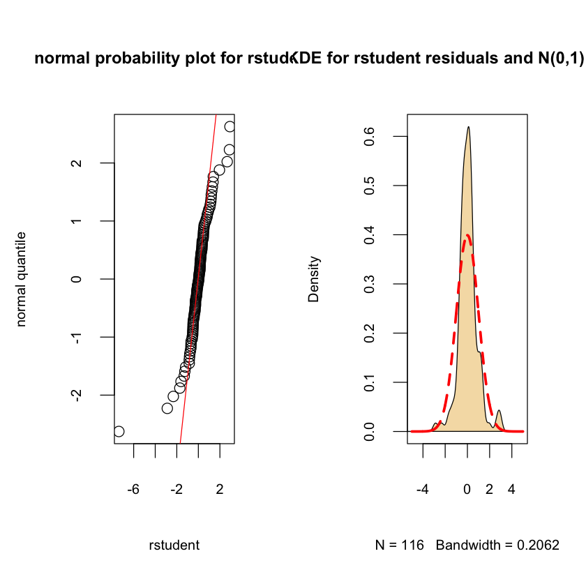

```r
par(mfrow=c(1,2))
qqnorm(rstudent(fit_Q3d), datax = TRUE,
       xlab = "normal quantile", # this is for the theoretical quantiles
       ylab = "rstudent", # this is for the sample quantiles
       main = "normal probability plot for rstudent")
qqline(rstudent(fit_Q3d), datax=TRUE, col = 2)
d <- density(rstudent(fit_Q3d), adjust = 1, na.rm = TRUE)
plot(d, type = "n", xlim=c(-5,5),
     main="KDE for rstudent residuals and N(0,1) density")
polygon(d, col = "wheat")
z = seq(from=-5,to=5,by=.01)
lines(z,dnorm(z), lty=2,lwd=3,col="red")
```

- The plot of absolute rstudent shows higher variance for smaller fitted values. So, the variance of error might be non-constant.

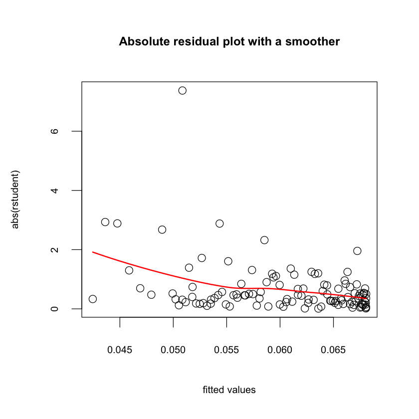

```r
plot(fitted(fit_Q3d), abs(rstudent(fit_Q3d)),
     xlab = "fitted values", ylab = "abs(rstudent)",
     main = "Absolute residual plot with a smoother")
smoother = loess(abs(rstudent(fit_Q3d)) ~ fitted(fit_Q3d))
ord = order(fitted(fit_Q3d)) # why do we need this line?
lines(fitted(fit_Q3d)[ord], fitted(smoother)[ord], col="red", lwd=2)
```

- The plot of rstudent vs. maturity shows no identifiable trend. However, the residuals seem to have some trend with MAT$^2$ and MAT$^3$.

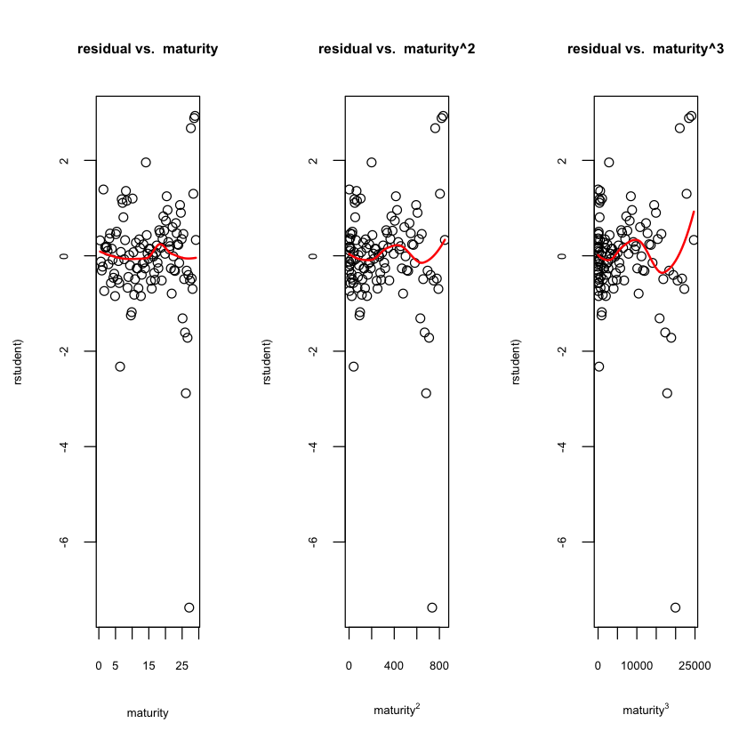

```r
par(mfrow=c(1,3))
preds = list(MAT, MAT2, MAT3)
labs = list("maturity", expression(maturity^2), expression(maturity^3))
for (p in 1:length(preds)) {
  X = preds[[p]]
  plot(X, rstudent(fit_Q3d),
       xlab = labs[[p]], ylab = "rstudent)",
       main = paste("residual vs. ", labs[[p]]))
  smoother = loess(rstudent(fit_Q3d) ~ X)
  ord = order(X)
  lines(X[ord], fitted(smoother)[ord], col="red", lwd=2)
}
```

- The sample ACF of the residuals indicate autocorrelation in the residual, although it is much less sever than the line regression model of part (a). This may still be a spurious regression.

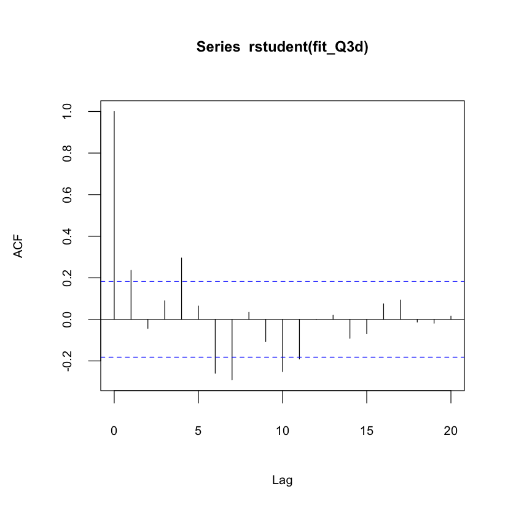

```r
acf(rstudent(fit_Q3d))
```

## (f)

(1 point) Can you detect collinearity (between predictors) in the model in part (d)?

**Solution:** The correlation plot and VIF values both indicate that high collinearity among predictors.

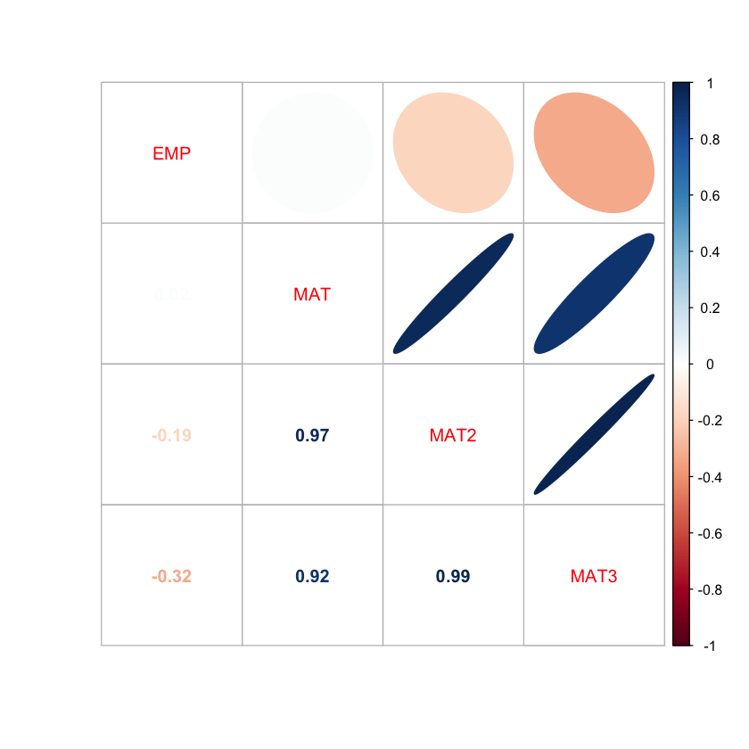

```r
DF_Q3f <- data.frame(EMP=EMP,
                 MAT=MAT,
                 MAT2=MAT2,
                 MAT3=MAT3)
corrplot.mixed(cor(DF_Q3f),upper="ellipse")
```

```r
vif(fit_Q3d)
```

**MAT**

107.99288549784

**MAT2**

614.998213870988

**MAT3**

237.384342133945